# Zadanie domowe - EDA Danych dotyczących Titanica

- Twoim zadaniem jest wykonanie analizy danych zawartych w załączonym pliku CSV (`26__titanic.csv`).
- Plik znajduje się pod video. Pamiętaj, żeby wrzucić plik do tego samego folderu, w którym znajduje się ten notebook.
- Wykorzystaj nowo nabytą wiedzę z biblioteki `Pandas`
- Jeżeli jest taka konieczność posiłkuj się [code explainerem](https://codeexplainer.imprv.ai/) lub / i [data chatterem](https://datachatter.imprv.ai/) (który również te dane ma dostępne).
- Prześlij na discordzie notebook z rozwiązaniem (`#modul-4-zad2`)
- Pamiętaj:
1. Nie spiesz się
2. Potraktuj zadanie domowe jak prawdziwy projekt
3. Dodawaj opisy, obserwacje, wnioski
4. Dodaj wizualizacje
5. Dodaj konkluzję i wnioski końcowe

Powodzenia!!! I mega zabawy!

## O Danych

Dane o pasażerach Titanica

Zbiór danych zawiera informacje o pasażerach RMS Titanic, który zatonął 15 kwietnia 1912 roku po zderzeniu z górą lodową. Dane obejmują takie atrybuty jak klasa podróży, wiek, płeć, liczba rodzeństwa/małżonków na pokładzie, liczba rodziców/dzieci na pokładzie, cena biletu oraz miejsce zaokrętowania.

Zbiór zawiera także informację o tym, czy pasażer przeżył katastrofę.

Titanic przewoził ponad 2,200 osób, z czego ponad 1,500 zginęło, co czyni tę katastrofę jedną z najbardziej tragicznych w historii morskiej.

Kolumny:

- **pclass** - Klasa biletu
- **survived** - Czy pasażer przeżył katastrofę
- **name** - Imię i nazwisko pasażera
- **sex** - Płeć pasażera
- **age** - Wiek pasażera
- **sibsp** - Liczba rodzeństwa/małżonków na pokładzie
- **parch** - Liczba rodziców/dzieci na pokładzie
- **ticket** - Numer biletu
- **fare** - Cena biletu
- **cabin** - Numer kabiny
- **embarked** - Port, w którym pasażer wszedł na pokład (C = Cherbourg, Q = Queenstown, S = Southampton)
- **boat** - Numer łodzi ratunkowej
- **body** - Numer ciała (jeśli pasażer nie przeżył i ciało zostało odnalezione)
- **home.dest** - Miejsce docelowe

# Ogólny przegląd danych

Najpierw obejrzę sobie całą bazę.

|  | pclass | survived | name | sex | age | sibsp | parch | ticket | fare | cabin | embarked | boat | body | home.dest |
| --- | --- | --- | --- | --- | --- | --- | --- | --- | --- | --- | --- | --- | --- | --- |
| 0 | 1.0 | 1.0 | Allen, Miss. Elisabeth Walton | female | 29.0000 | 0.0 | 0.0 | 24160 | 211.3375 | B5 | S | 2 | NaN | St Louis, MO |
| 1 | 1.0 | 1.0 | Allison, Master. Hudson Trevor | male | 0.9167 | 1.0 | 2.0 | 113781 | 151.5500 | C22 C26 | S | 11 | NaN | Montreal, PQ / Chesterville, ON |
| 2 | 1.0 | 0.0 | Allison, Miss. Helen Loraine | female | 2.0000 | 1.0 | 2.0 | 113781 | 151.5500 | C22 C26 | S | NaN | NaN | Montreal, PQ / Chesterville, ON |
| 3 | 1.0 | 0.0 | Allison, Mr. Hudson Joshua Creighton | male | 30.0000 | 1.0 | 2.0 | 113781 | 151.5500 | C22 C26 | S | NaN | 135.0 | Montreal, PQ / Chesterville, ON |
| 4 | 1.0 | 0.0 | Allison, Mrs. Hudson J C (Bessie Waldo Daniels) | female | 25.0000 | 1.0 | 2.0 | 113781 | 151.5500 | C22 C26 | S | NaN | NaN | Montreal, PQ / Chesterville, ON |
| ... | ... | ... | ... | ... | ... | ... | ... | ... | ... | ... | ... | ... | ... | ... |
| 1305 | 3.0 | 0.0 | Zabour, Miss. Thamine | female | NaN | 1.0 | 0.0 | 2665 | 14.4542 | NaN | C | NaN | NaN | NaN |
| 1306 | 3.0 | 0.0 | Zakarian, Mr. Mapriededer | male | 26.5000 | 0.0 | 0.0 | 2656 | 7.2250 | NaN | C | NaN | 304.0 | NaN |
| 1307 | 3.0 | 0.0 | Zakarian, Mr. Ortin | male | 27.0000 | 0.0 | 0.0 | 2670 | 7.2250 | NaN | C | NaN | NaN | NaN |
| 1308 | 3.0 | 0.0 | Zimmerman, Mr. Leo | male | 29.0000 | 0.0 | 0.0 | 315082 | 7.8750 | NaN | S | NaN | NaN | NaN |
| 1309 | NaN | NaN | NaN | NaN | NaN | NaN | NaN | NaN | NaN | NaN | NaN | NaN | NaN | NaN |

1310 rows × 14 columns

W bazie jest 1310 rekordów. Jeśli jest to tylko lista pasażerów (bez załogi) to wygląda na w miarę kompletną. Wikipedia podaje, że na Titanicu było 1311 pasażerów i 897 członków załogi. Dane te, jednak, zmieniają się w zależności od źródła, więc liczba 1310 pasażerów wydaje się dostatecznie dokładną.

Zobaczmy listę kolumn.

```
Index(['pclass', 'survived', 'name', 'sex', 'age', 'sibsp', 'parch', 'ticket',
       'fare', 'cabin', 'embarked', 'boat', 'body', 'home.dest'],
      dtype='object')
```

Lista kolumn zgodna z opisem.

Zróbmy próbkę losową rekordów.

|  | pclass | survived | name | sex | age | sibsp | parch | ticket | fare | cabin | embarked | boat | body | home.dest |
| --- | --- | --- | --- | --- | --- | --- | --- | --- | --- | --- | --- | --- | --- | --- |
| 1011 | 3.0 | 0.0 | McNamee, Mrs. Neal (Eileen O'Leary) | female | 19.0 | 1.0 | 0.0 | 376566 | 16.1000 | NaN | S | NaN | 53.0 | NaN |
| 188 | 1.0 | 1.0 | Lines, Mrs. Ernest H (Elizabeth Lindsey James) | female | 51.0 | 0.0 | 1.0 | PC 17592 | 39.4000 | D28 | S | 9 | NaN | Paris, France |
| 869 | 3.0 | 0.0 | Holthen, Mr. Johan Martin | male | 28.0 | 0.0 | 0.0 | C 4001 | 22.5250 | NaN | S | NaN | NaN | NaN |
| 239 | 1.0 | 0.0 | Roebling, Mr. Washington Augustus II | male | 31.0 | 0.0 | 0.0 | PC 17590 | 50.4958 | A24 | S | NaN | NaN | Trenton, NJ |
| 1208 | 3.0 | 0.0 | Skoog, Miss. Mabel | female | 9.0 | 3.0 | 2.0 | 347088 | 27.9000 | NaN | S | NaN | NaN | NaN |
| 486 | 2.0 | 0.0 | Leyson, Mr. Robert William Norman | male | 24.0 | 0.0 | 0.0 | C.A. 29566 | 10.5000 | NaN | S | NaN | 108.0 | NaN |
| 163 | 1.0 | 1.0 | Holverson, Mrs. Alexander Oskar (Mary Aline To... | female | 35.0 | 1.0 | 0.0 | 113789 | 52.0000 | NaN | S | 8 | NaN | New York, NY |
| 202 | 1.0 | 1.0 | McGough, Mr. James Robert | male | 36.0 | 0.0 | 0.0 | PC 17473 | 26.2875 | E25 | S | 7 | NaN | Philadelphia, PA |
| 522 | 2.0 | 0.0 | Otter, Mr. Richard | male | 39.0 | 0.0 | 0.0 | 28213 | 13.0000 | NaN | S | NaN | NaN | Middleburg Heights, OH |
| 596 | 2.0 | 1.0 | Wilhelms, Mr. Charles | male | 31.0 | 0.0 | 0.0 | 244270 | 13.0000 | NaN | S | 9 | NaN | London, England |

Widać, że niektórzy zajmowali kilka kabin - pewnie mieli dzięki temu coś w rodzaju biura lub apartamentu.

W części liczbowej (wiek, rodzina, nr biletu, cena) dane wyglądają dość dobze. Brak numeru łodzi, do której wsiadł będę chyba traktował jak informację, że nie wsiadł. Brak ciała też jest dość oczywisty - chyba większości ciał nie znaleziono. Brak miejsca docelowego jest faktycznym brakiem w danych. Każdy dokądś zmierzał tylko się pewnie nie przyznał.

Ciekawe, że dane o tym czy osoba przeżyła są podane w formacie liczby.

I jeszcze trochę danych ogólnych o bazie i zawartych w niej danych.

```
<class 'pandas.core.frame.DataFrame'>
RangeIndex: 1310 entries, 0 to 1309
Data columns (total 14 columns):
 #   Column     Non-Null Count  Dtype
---  ------     --------------  -----
 0   pclass     1309 non-null   float64
 1   survived   1309 non-null   float64
 2   name       1309 non-null   object
 3   sex        1309 non-null   object
 4   age        1046 non-null   float64
 5   sibsp      1309 non-null   float64
 6   parch      1309 non-null   float64
 7   ticket     1309 non-null   object
 8   fare       1308 non-null   float64
 9   cabin      295 non-null    object
 10  embarked   1307 non-null   object
 11  boat       486 non-null    object
 12  body       121 non-null    float64
 13  home.dest  745 non-null    object
dtypes: float64(7), object(7)
memory usage: 143.4+ KB
```

Widać, że podstawowe dane (klasa, czy przeżył, nazwisko, płeć, informacje o rodzinie, numery biletów) są kompletne. Jest trochę braków w danych o wieku, jedna brakująca informacja o taryfie, 2 osoby nie wiadomo gdzie wsiadły.

Najsłabiej wygląda informacja o kabinie (tylko 295 osób ma przypisane numery) i o celu podróży - tylko połowa je podała.

Zastanawiam się też co zrobić z informacją o znalezionych ciałach oraz o łodziach ratunkowych. Równie dobrze może to być informacja prawdziwa, jak i dane wypełnione tylko częściowo. Temat do przemyślenia.

|  | pclass | survived | age | sibsp | parch | fare | body |
| --- | --- | --- | --- | --- | --- | --- | --- |
| count | 1309.000000 | 1309.000000 | 1046.000000 | 1309.000000 | 1309.000000 | 1308.000000 | 121.000000 |
| mean | 2.294882 | 0.381971 | 29.881135 | 0.498854 | 0.385027 | 33.295479 | 160.809917 |
| std | 0.837836 | 0.486055 | 14.413500 | 1.041658 | 0.865560 | 51.758668 | 97.696922 |
| min | 1.000000 | 0.000000 | 0.166700 | 0.000000 | 0.000000 | 0.000000 | 1.000000 |
| 25% | 2.000000 | 0.000000 | 21.000000 | 0.000000 | 0.000000 | 7.895800 | 72.000000 |
| 50% | 3.000000 | 0.000000 | 28.000000 | 0.000000 | 0.000000 | 14.454200 | 155.000000 |
| 75% | 3.000000 | 1.000000 | 39.000000 | 1.000000 | 0.000000 | 31.275000 | 256.000000 |
| max | 3.000000 | 1.000000 | 80.000000 | 8.000000 | 9.000000 | 512.329200 | 328.000000 |

Tego typu analiza (średnia, kwartyle, minimmum, maksimum) raczej nie ma sensu w przypadku danych o Titanicu. Można ewentualnie popatrzeć na średni wiek pasażera lub średnią cenę biletu).

Trochę niepokoi informacja, że najniższa cena biletu wynosiła 0. Chyba nikt za darmo nie popłynął, więc raczej to jest błąd w danych. Sprawdzę ile jest takich rekordów.

```
Liczba biletów w taryfie 0 wynosi 17
```

Siedemmnaście rekordów - to niewiele. Zobaczmy je.

|  | pclass | survived | name | sex | age | sibsp | parch | ticket | fare | cabin | embarked | boat | body | home.dest |
| --- | --- | --- | --- | --- | --- | --- | --- | --- | --- | --- | --- | --- | --- | --- |
| 7 | 1.0 | 0.0 | Andrews, Mr. Thomas Jr | male | 39.0 | 0.0 | 0.0 | 112050 | 0.0 | A36 | S | NaN | NaN | Belfast, NI |
| 70 | 1.0 | 0.0 | Chisholm, Mr. Roderick Robert Crispin | male | NaN | 0.0 | 0.0 | 112051 | 0.0 | NaN | S | NaN | NaN | Liverpool, England / Belfast |
| 125 | 1.0 | 0.0 | Fry, Mr. Richard | male | NaN | 0.0 | 0.0 | 112058 | 0.0 | B102 | S | NaN | NaN | NaN |
| 150 | 1.0 | 0.0 | Harrison, Mr. William | male | 40.0 | 0.0 | 0.0 | 112059 | 0.0 | B94 | S | NaN | 110.0 | NaN |
| 170 | 1.0 | 1.0 | Ismay, Mr. Joseph Bruce | male | 49.0 | 0.0 | 0.0 | 112058 | 0.0 | B52 B54 B56 | S | C | NaN | Liverpool |
| 223 | 1.0 | 0.0 | Parr, Mr. William Henry Marsh | male | NaN | 0.0 | 0.0 | 112052 | 0.0 | NaN | S | NaN | NaN | Belfast |
| 234 | 1.0 | 0.0 | Reuchlin, Jonkheer. John George | male | 38.0 | 0.0 | 0.0 | 19972 | 0.0 | NaN | S | NaN | NaN | Rotterdam, Netherlands |
| 363 | 2.0 | 0.0 | Campbell, Mr. William | male | NaN | 0.0 | 0.0 | 239853 | 0.0 | NaN | S | NaN | NaN | Belfast |
| 384 | 2.0 | 0.0 | Cunningham, Mr. Alfred Fleming | male | NaN | 0.0 | 0.0 | 239853 | 0.0 | NaN | S | NaN | NaN | Belfast |
| 410 | 2.0 | 0.0 | Frost, Mr. Anthony Wood "Archie" | male | NaN | 0.0 | 0.0 | 239854 | 0.0 | NaN | S | NaN | NaN | Belfast |
| 473 | 2.0 | 0.0 | Knight, Mr. Robert J | male | NaN | 0.0 | 0.0 | 239855 | 0.0 | NaN | S | NaN | NaN | Belfast |
| 528 | 2.0 | 0.0 | Parkes, Mr. Francis "Frank" | male | NaN | 0.0 | 0.0 | 239853 | 0.0 | NaN | S | NaN | NaN | Belfast |
| 581 | 2.0 | 0.0 | Watson, Mr. Ennis Hastings | male | NaN | 0.0 | 0.0 | 239856 | 0.0 | NaN | S | NaN | NaN | Belfast |
| 896 | 3.0 | 0.0 | Johnson, Mr. Alfred | male | 49.0 | 0.0 | 0.0 | LINE | 0.0 | NaN | S | NaN | NaN | NaN |
| 898 | 3.0 | 0.0 | Johnson, Mr. William Cahoone Jr | male | 19.0 | 0.0 | 0.0 | LINE | 0.0 | NaN | S | NaN | NaN | NaN |
| 963 | 3.0 | 0.0 | Leonard, Mr. Lionel | male | 36.0 | 0.0 | 0.0 | LINE | 0.0 | NaN | S | NaN | NaN | NaN |
| 1254 | 3.0 | 1.0 | Tornquist, Mr. William Henry | male | 25.0 | 0.0 | 0.0 | LINE | 0.0 | NaN | S | 15 | NaN | NaN |

Widać, że te rekordy z ceną zero jakoś się grupują po serii biletów i po nazwiskach. Jest tam kilka przypadków z numerem biletu "LINE", jest kilka przypadków z numerami w okolicy 239853, 4, 5, 6 i kilka przypadków z numerami biletów w okolicy 112050, 1, 2, 3....

Przy okazji już widać, że numery biletów nie są unikalne i się powtarzają. Co to może znaczyć? Sfałszowane bilety czy pomyłki?

# Analiza brakujących wartości

Robię ten krok gwoli formalności. Z poprzedniej analizy już widać ile danych brakuje.

```
pclass          1
survived        1
name            1
sex             1
age           264
sibsp           1
parch           1
ticket          1
fare            2
cabin        1015
embarked        3
boat          824
body         1189
home.dest     565
dtype: int64
```

Sprawdźmy jeszcze czy są jakieś rekordy zduplikowane.

```
False    1310
Name: Duplikat, dtype: int64
```

Nie ma duplikatów. Super.

Wyrzucę kolumnę z informacją o duplikacie bo będzie mi później przeszkadzać.

# Analiza pojedyńczych zmiennych

Podczas analizy pojedyńczych zmiennych z naszej bazy danych będę porównywał zawarte tam informacje z Wikipedią aby ocenić wiarygodność i przydatność tych danych.

Zobaczmy po ile wartości unikalnych mamy w każdej kolumnie.

```
pclass          3
survived        2
name         1307
sex             2
age            98
sibsp           7
parch           8
ticket        929
fare          281
cabin         186
embarked        3
boat           27
body          121
home.dest     369
dtype: int64
```

## Klasa

```
3.0    709
1.0    323
2.0    277
Name: pclass, dtype: int64
```

Zostawiam - nie przesuwam pasażerów między klasami.

## Przeżywalność

```
0.0    809
1.0    500
Name: survived, dtype: int64
```

Mamy 500 ocalałych, a Wikipedia mówi o 492 ocalałych pasażerach. Ten sam komentarz co powyżej. Nie poprawiam, bo nie mam jak tego uwiarygodnić. Gdybym miał jakąś drugą listę to może po nazwiskach, ale wtedy powstaje pytanie, która lista jest właściwa.

## Nazwisko

Popatrzmy na nazwiska

```
Kelly, Mr. James                     2
Connolly, Miss. Kate                 2
Ilmakangas, Miss. Ida Livija         1
Ilieff, Mr. Ylio                     1
Ibrahim Shawah, Mr. Yousseff         1
                                    ..
Harris, Mr. George                   1
Harper, Rev. John                    1
Harper, Miss. Annie Jessie "Nina"    1
Harbeck, Mr. William H               1
Herman, Mr. Samuel                   1
Name: name, Length: 1307, dtype: int64
```

Widać, że ta kolumna jest wypełniona w sposób bardzo utrudniający analizę. Trzeba będzie coś z nią zrobić - wydzielić nazwiska, oddzielić tytuły i imiona

## Płeć

```
male      843
female    466
Name: sex, dtype: int64
```

Wśród pasażerów widać było wyraźną przewagę mężczyzn.

## Wiek

Tutaj pokuszę się o wykres

```
array([[<Axes: title={'center': 'age'}>]], dtype=object)
```

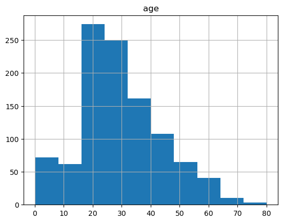

Wielu młodych ludzi. To pewnie obraz emigracji na drugą stronę Atlantyku.

## Rodzeństwo

```
0.0    891
1.0    319
2.0     42
4.0     22
3.0     20
8.0      9
5.0      6
Name: sibsp, dtype: int64
```

Dane w tej kolumnie wygladają bardzo dobrze, z punktu widzenia możliwości analizy. Nie wiem tylko czy będą przydatne.

## Rodzice i dzieci

```
0.0    1002
1.0     170
2.0     113
3.0       8
4.0       6
5.0       6
6.0       2
9.0       2
Name: parch, dtype: int64
```

Podobnie jak w przypadku rodzeństwa - dobre dane tylko nie wiem czy się do czegoś przydadzą.

## Numer biletu

Mamy 929 unikalnych numerów biletów na 1310 pasażerów. Widziałem, że są tam bilety z wpisem "LINE" - tak jakby sprzedawane przez inną organizację.

```
Liczba biletów typu LINE: 4
```

Tylko cztery, czyli reszta dublujących się numerów biletów to najprawdopodobniej pomyłki lub fałszywki. Sporo! Podrążę jeszcze ten temat.

```
ticket
CA. 2343        10
CA 2144          7
1601             7
PC 17608         6
S.O.C. 14879     6
                ..
2665             1
26707            1
2680             1
2689             1
250651           1
Length: 216, dtype: int64
```

```
pclass                  3
survived                2
name                  380
sex                     2
age                    74
sibsp                   7
parch                   8
ticket                216
fare                  147
cabin                  94
embarked                3
boat                   22
body                   26
home.dest             139
Zduplikowany Bilet      1
dtype: int64
```

Zatem mamy 216 różnych numerów biletów, z których każdy występuje po 2 lub więcej razy. Nie wiem czy będę potrzebował do dalszych analiz numerów biletów, ale jeśli tak to jest to problem. Bo te dane wydają się bardzo mało przydatne.

Wyrzucam kolumnę z informacją o zduplikowanym bilecie.

## Taryfa

Zobaczmy to na wykresie

```
array([[<Axes: title={'center': 'fare'}>]], dtype=object)
```

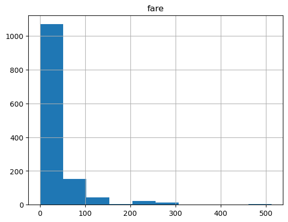

Najniższa taryfa dominuje, więc reszty nie widać. Zrobię listę.

```
8.0500     60
13.0000    59
7.7500     55
26.0000    50
7.8958     49
           ..
7.2833      1
7.8208      1
9.6875      1
15.0500     1
12.7375     1
Name: fare, Length: 281, dtype: int64
```

Tak też niewiele widać. Może tak?

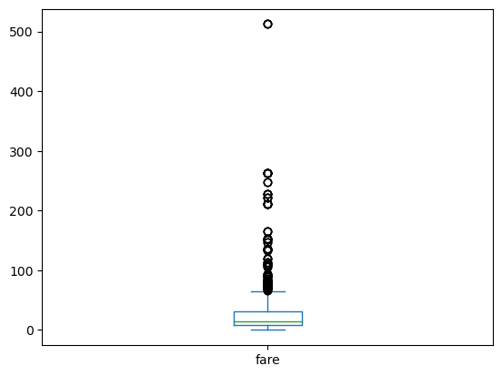

... też słabo...

```
count    1308.000000
mean       33.295479
std        51.758668
min         0.000000
25%         7.895800
50%        14.454200
75%        31.275000
max       512.329200
Name: fare, dtype: float64
```

Chyba tylko tak możemy coś wyczytać. Tyle, że trzeba wyeliminować zerowe ceny z analizy.

## Kabiny

```
C23 C25 C27        6
G6                 5
B57 B59 B63 B66    5
C78                4
F4                 4
                  ..
F E69              1
E10                1
A5                 1
C51                1
B42                1
Name: cabin, Length: 186, dtype: int64
```

Witać, że jest trochę bałaganu w tych danych, ale może to jest logiczne. W końcu w jednej kabinie może mieszkać wiecej osób oraz może też być tak, że jedna osoba zajmuje wiele kabin. Może też być tak, że kilka kabin jest łącznie przypisane do kilku osób (do rodziny). Zobaczmy...

|  | pclass | survived | name | sex | age | sibsp | parch | ticket | fare | cabin | embarked | boat | body | home.dest |
| --- | --- | --- | --- | --- | --- | --- | --- | --- | --- | --- | --- | --- | --- | --- |
| 111 | 1.0 | 1.0 | Fortune, Miss. Alice Elizabeth | female | 24.0 | 3.0 | 2.0 | 19950 | 263.0 | C23 C25 C27 | S | 10 | NaN | Winnipeg, MB |
| 112 | 1.0 | 1.0 | Fortune, Miss. Ethel Flora | female | 28.0 | 3.0 | 2.0 | 19950 | 263.0 | C23 C25 C27 | S | 10 | NaN | Winnipeg, MB |
| 113 | 1.0 | 1.0 | Fortune, Miss. Mabel Helen | female | 23.0 | 3.0 | 2.0 | 19950 | 263.0 | C23 C25 C27 | S | 10 | NaN | Winnipeg, MB |
| 114 | 1.0 | 0.0 | Fortune, Mr. Charles Alexander | male | 19.0 | 3.0 | 2.0 | 19950 | 263.0 | C23 C25 C27 | S | NaN | NaN | Winnipeg, MB |
| 115 | 1.0 | 0.0 | Fortune, Mr. Mark | male | 64.0 | 1.0 | 4.0 | 19950 | 263.0 | C23 C25 C27 | S | NaN | NaN | Winnipeg, MB |
| 116 | 1.0 | 1.0 | Fortune, Mrs. Mark (Mary McDougald) | female | 60.0 | 1.0 | 4.0 | 19950 | 263.0 | C23 C25 C27 | S | 10 | NaN | Winnipeg, MB |

Ogólnie dane o numerach kabin wydają sie niekompletne i trudne do wykorzystania.

- po pierwsze brakuje wpisów w ponad 1000 rekordów, podczas gdy pasażerów klasy 3 (jak przypuszczam, bez kabiny) było tylko 700.
- wpisy się dublują w różnych kombinacjach i niejednokrotnie te zdublowane dane wcale nie świadczą o błędach

## Miejsce, gdzie wsiedli

```
S    914
C    270
Q    123
Name: embarked, dtype: int64
```

Litery oznaczają Southampton, Cherburg i Queenstown

## Łodzie ratunkowe

```
13         39
C          38
15         37
14         33
4          31
10         29
5          27
3          26
9          25
11         25
8          23
16         23
7          23
D          20
6          20
12         19
2          13
A          11
B           9
1           5
13 15       2
5 7         2
C D         2
5 9         1
8 10        1
13 15 B     1
15 16       1
Name: boat, dtype: int64
```

Widać, że z danymi o łodziach ratunkowych będzie kłopot. Mamy liczby i litery. Do niektórych osób przypisane są dwie lub nawet 3 łodzie. Taka sytuacja mogła dotyczyć kabin, ale nie łodzi ratunkowych. W Wikipedii czytamy, że na statku było 16 szalup. To zgadzałoby się z numerami występującymi w bazie danych, ale co oznaczają litery (A, B, C i D)?

## Czy znaleziono ciało

Tutaj należałoby przeanalizować tylko te przypadki, w których dana osoba zginęła. Zobaczmy jak te dane wyglądają.

```
304.0    1
7.0      1
32.0     1
67.0     1
284.0    1
        ..
208.0    1
172.0    1
269.0    1
62.0     1
133.0    1
Name: body, Length: 121, dtype: int64
```

```
body
328.0    1
293.0    1
294.0    1
295.0    1
297.0    1
        ..
14.0     1
15.0     1
16.0     1
17.0     1
18.0     1
Length: 121, dtype: int64
```

OK, widać, że nie ma błędów - wszystkie numery ciał przypisane są do zmarłych, nie do żyjących.

## Początek i cel podróży

```
New York, NY                         64
London                               14
Montreal, PQ                         10
Paris, France                         9
Cornwall / Akron, OH                  9
                                     ..
Birkdale, England Cleveland, Ohio     1
London / Winnipeg, MB                 1
Cooperstown, NY                       1
Pomeroy, WA                           1
Omaha, NE                             1
Name: home.dest, Length: 369, dtype: int64
```

```
565
```

565 brakujących wpisów. Dodatkowo widać, że w jednej komórce zapisano skąd i dokąd ktoś płynął. Spróbuję je trochę poprawić ale nie będzie łatwo.

# Transformacja danych

Pozostałe dane nie wymagają korekt.

## Zmiana nazw kolumn

|  | Klasa | Uratowany | Tożsamość | Płeć | Wiek | Rodzeństwo | Rodzice/Dzieci | Numer biletu | Cena biletu | Numer kabiny | Port zaokrętowania | Numer szalupy | Numer ciała | Początek i cel |
| --- | --- | --- | --- | --- | --- | --- | --- | --- | --- | --- | --- | --- | --- | --- |
| 444 | 2.0 | 0.0 | Hickman, Mr. Stanley George | male | 21.0 | 2.0 | 0.0 | S.O.C. 14879 | 73.5 | NaN | S | NaN | NaN | West Hampstead, London / Neepawa, MB |

OK

## Wydzielenie nazwisk, imion i tytułów

|  | Klasa | Uratowany | Tożsamość | Płeć | Wiek | Rodzeństwo | Rodzice/Dzieci | Numer biletu | Cena biletu | Numer kabiny | Port zaokrętowania | Numer szalupy | Numer ciała | Początek i cel |
| --- | --- | --- | --- | --- | --- | --- | --- | --- | --- | --- | --- | --- | --- | --- |
| 473 | 2.0 | 0.0 | Knight, Mr. Robert J | male | NaN | 0.0 | 0.0 | 239855 | 0.0000 | NaN | S | NaN | NaN | Belfast |
| 288 | 1.0 | 1.0 | Swift, Mrs. Frederick Joel (Margaret Welles Ba... | female | 48.0 | 0.0 | 0.0 | 17466 | 25.9292 | D17 | S | 8 | NaN | Brooklyn, NY |
| 498 | 2.0 | 0.0 | McCrae, Mr. Arthur Gordon | male | 32.0 | 0.0 | 0.0 | 237216 | 13.5000 | NaN | S | NaN | 209.0 | Sydney, Australia |
| 1092 | 3.0 | 0.0 | Oreskovic, Mr. Luka | male | 20.0 | 0.0 | 0.0 | 315094 | 8.6625 | NaN | S | NaN | NaN | NaN |
| 163 | 1.0 | 1.0 | Holverson, Mrs. Alexander Oskar (Mary Aline To... | female | 35.0 | 1.0 | 0.0 | 113789 | 52.0000 | NaN | S | 8 | NaN | New York, NY |
| 37 | 1.0 | 1.0 | Bradley, Mr. George ("George Arthur Brayton") | male | NaN | 0.0 | 0.0 | 111427 | 26.5500 | NaN | S | 9 | NaN | Los Angeles, CA |
| 910 | 3.0 | 0.0 | Kallio, Mr. Nikolai Erland | male | 17.0 | 0.0 | 0.0 | STON/O 2. 3101274 | 7.1250 | NaN | S | NaN | NaN | NaN |
| 210 | 1.0 | 0.0 | Molson, Mr. Harry Markland | male | 55.0 | 0.0 | 0.0 | 113787 | 30.5000 | C30 | S | NaN | NaN | Montreal, PQ |
| 904 | 3.0 | 0.0 | Jonkoff, Mr. Lalio | male | 23.0 | 0.0 | 0.0 | 349204 | 7.8958 | NaN | S | NaN | NaN | NaN |
| 1088 | 3.0 | 1.0 | Olsson, Mr. Oscar Wilhelm | male | 32.0 | 0.0 | 0.0 | 347079 | 7.7750 | NaN | S | A | NaN | NaN |
| 243 | 1.0 | 0.0 | Rosenshine, Mr. George ("Mr George Thorne") | male | 46.0 | 0.0 | 0.0 | PC 17585 | 79.2000 | NaN | C | NaN | 16.0 | New York, NY |
| 623 | 3.0 | 0.0 | Andersson, Miss. Ebba Iris Alfrida | female | 6.0 | 4.0 | 2.0 | 347082 | 31.2750 | NaN | S | NaN | NaN | Sweden Winnipeg, MN |
| 1304 | 3.0 | 0.0 | Zabour, Miss. Hileni | female | 14.5 | 1.0 | 0.0 | 2665 | 14.4542 | NaN | C | NaN | 328.0 | NaN |
| 975 | 3.0 | 0.0 | Lobb, Mrs. William Arthur (Cordelia K Stanlick) | female | 26.0 | 1.0 | 0.0 | A/5. 3336 | 16.1000 | NaN | S | NaN | NaN | NaN |
| 591 | 2.0 | 1.0 | West, Miss. Constance Mirium | female | 5.0 | 1.0 | 2.0 | C.A. 34651 | 27.7500 | NaN | S | 10 | NaN | Bournmouth, England |
| 177 | 1.0 | 1.0 | Kimball, Mr. Edwin Nelson Jr | male | 42.0 | 1.0 | 0.0 | 11753 | 52.5542 | D19 | S | 5 | NaN | Boston, MA |
| 1236 | 3.0 | 1.0 | Svensson, Mr. Johan Cervin | male | 14.0 | 0.0 | 0.0 | 7538 | 9.2250 | NaN | S | 13 | NaN | NaN |
| 1165 | 3.0 | 0.0 | Saad, Mr. Khalil | male | 25.0 | 0.0 | 0.0 | 2672 | 7.2250 | NaN | C | NaN | NaN | NaN |
| 96 | 1.0 | 0.0 | Douglas, Mr. Walter Donald | male | 50.0 | 1.0 | 0.0 | PC 17761 | 106.4250 | C86 | C | NaN | 62.0 | Deephaven, MN / Cedar Rapids, IA |
| 1163 | 3.0 | 0.0 | Ryan, Mr. Patrick | male | NaN | 0.0 | 0.0 | 371110 | 24.1500 | NaN | Q | NaN | NaN | NaN |

Logika wpisów tożsamości, którą dostrzegam:

1. Nazwisko
2. Przecinek i spacja
3. Tytuł
4. Kropka i spacja
5. Pierwsze imię dla mężczyzn i kobiet niezamężnych. Pierwsze imię męża dla kobiet zamężnych (pamietam z początków nauki Angielskiego, że Brytyjczycy tak zapisywali :-))
6. Spacja
7. Drugie imię
8. Spacja
9. Dalej opcjonalnie
10. dla kobiet zamężnych
    - Otworzyć nawias
    - Imię
    - Spacja (może nie wystąpić)
    - Nazwisko panieńskie (może nie wystąpić)
    - Zamknąć nawias
11. dla innych osób
    - otworzyć cudzysłów
    - pseudonim
    - zamknąć cudzysłów

Wszystkich danych nie potrzebuję. Wyodrębnię: tytuł, imię i nazwisko.

Najpierw dodam kolumny wypełniając je wstępnie danymi nieznanymi.

Pomogę sobie Data Chatterem

## Informacja czy wsiadł do szalupy

Dodam kolumnę wskazującą na to czy przy danym nazwisku pojawił się jakikolwiek numer szalupy. Jeśli tak, to zakładam że ta osoba wsiadła do szalupy. Jeśli nie - to nie.

## Początek i cel podróży

Na koniec korekt uzupełnię wpisy w kolumnie z celem podróży.

|  | Klasa | Uratowany | Tożsamość | Płeć | Wiek | Rodzeństwo | Rodzice/Dzieci | Numer biletu | Cena biletu | Numer kabiny | Port zaokrętowania | Numer szalupy | Numer ciała | Początek i cel | Tytuł | Imię | Nazwisko | W szalupie |
| --- | --- | --- | --- | --- | --- | --- | --- | --- | --- | --- | --- | --- | --- | --- | --- | --- | --- | --- |
| 648 | 3.0 | 0.0 | Assaf, Mr. Gerios | male | 21.0 | 0.0 | 0.0 | 2692 | 7.2250 | NaN | C | NaN | NaN | Ottawa, ON | Mr. | Gerios | Assaf | False |
| 997 | 3.0 | 1.0 | Masselmani, Mrs. Fatima | female | NaN | 0.0 | 0.0 | 2649 | 7.2250 | NaN | C | C | NaN | Nieznany | Mrs. | None | Masselmani | True |
| 690 | 3.0 | 0.0 | Brobeck, Mr. Karl Rudolf | male | 22.0 | 0.0 | 0.0 | 350045 | 7.7958 | NaN | S | NaN | NaN | Sweden Worcester, MA | Mr. | Karl | Brobeck | False |
| 534 | 2.0 | 1.0 | Phillips, Miss. Kate Florence ("Mrs Kate Louis... | female | 19.0 | 0.0 | 0.0 | 250655 | 26.0000 | NaN | S | 11 | NaN | Worcester, England | Miss. | Kate | Phillips | True |
| 1225 | 3.0 | 0.0 | Storey, Mr. Thomas | male | 60.5 | 0.0 | 0.0 | 3701 | NaN | NaN | S | NaN | 261.0 | Nieznany | Mr. | Thomas | Storey | False |
| 933 | 3.0 | 0.0 | Kink, Mr. Vincenz | male | 26.0 | 2.0 | 0.0 | 315151 | 8.6625 | NaN | S | NaN | NaN | Nieznany | Mr. | Vincenz | Kink | False |
| 113 | 1.0 | 1.0 | Fortune, Miss. Mabel Helen | female | 23.0 | 3.0 | 2.0 | 19950 | 263.0000 | C23 C25 C27 | S | 10 | NaN | Winnipeg, MB | Miss. | Mabel | Fortune | True |
| 510 | 2.0 | 0.0 | Mudd, Mr. Thomas Charles | male | 16.0 | 0.0 | 0.0 | S.O./P.P. 3 | 10.5000 | NaN | S | NaN | NaN | Halesworth, England | Mr. | Thomas | Mudd | False |
| 497 | 2.0 | 0.0 | Maybery, Mr. Frank Hubert | male | 40.0 | 0.0 | 0.0 | 239059 | 16.0000 | NaN | S | NaN | NaN | Weston-Super-Mare / Moose Jaw, SK | Mr. | Frank | Maybery | False |
| 1112 | 3.0 | 0.0 | Peacock, Miss. Treasteall | female | 3.0 | 1.0 | 1.0 | SOTON/O.Q. 3101315 | 13.7750 | NaN | S | NaN | NaN | Nieznany | Miss. | Treasteall | Peacock | False |

# Analiza korelacji pomiędzy zmiennymi

Zrobię ogólną analizę korelacji, a później zajmę się zbadaniem zależności wybranych bardziej świadomie.

|  | Klasa | Uratowany | Wiek | Rodzeństwo | Rodzice/Dzieci | Cena biletu | Numer ciała | W szalupie |
| --- | --- | --- | --- | --- | --- | --- | --- | --- |
| Klasa | 1.000000 | -0.312469 | -0.408106 | 0.060832 | 0.018322 | -0.558629 | -0.034642 | -0.323428 |
| Uratowany | -0.312469 | 1.000000 | -0.055513 | -0.027825 | 0.082660 | 0.244265 | NaN | 0.948190 |
| Wiek | -0.408106 | -0.055513 | 1.000000 | -0.243699 | -0.150917 | 0.178739 | 0.058809 | -0.053176 |
| Rodzeństwo | 0.060832 | -0.027825 | -0.243699 | 1.000000 | 0.373587 | 0.160238 | -0.099961 | -0.026488 |
| Rodzice/Dzieci | 0.018322 | 0.082660 | -0.150917 | 0.373587 | 1.000000 | 0.221539 | 0.051099 | 0.089321 |
| Cena biletu | -0.558629 | 0.244265 | 0.178739 | 0.160238 | 0.221539 | 1.000000 | -0.043110 | 0.252717 |
| Numer ciała | -0.034642 | NaN | 0.058809 | -0.099961 | 0.051099 | -0.043110 | 1.000000 | NaN |
| W szalupie | -0.323428 | 0.948190 | -0.053176 | -0.026488 | 0.089321 | 0.252717 | NaN | 1.000000 |

# Analiza

Na tym etapie trzeba już wiedzieć czego szukamy. Jakie jest pytanie (nasze lub klienta), na które chcemy znaleźć odpowiedź. Można sobie wymyślić wiele różnych analiz, które zależnie od rodzaju i jakości danych będą mniej lub bardziej ciekawe. Ja zadam sobie trzy pytania:

1. Czy osoby podróżujące w klasie pierwszej miały pierwszeństwo przy wsiadaniu do szalup?
2. Czy kobiety i dzieci miały pierwszeństwo przy wsiadaniu do szalup?
3. Czy wśród tych, którzy nie wsiedli do szalup wiek miał wpływ na ich szanse przeżycia?

## Czy osoby podróżujące w klasie pierwszej miały pierwszeństwo przy wsiadaniu do szalup?

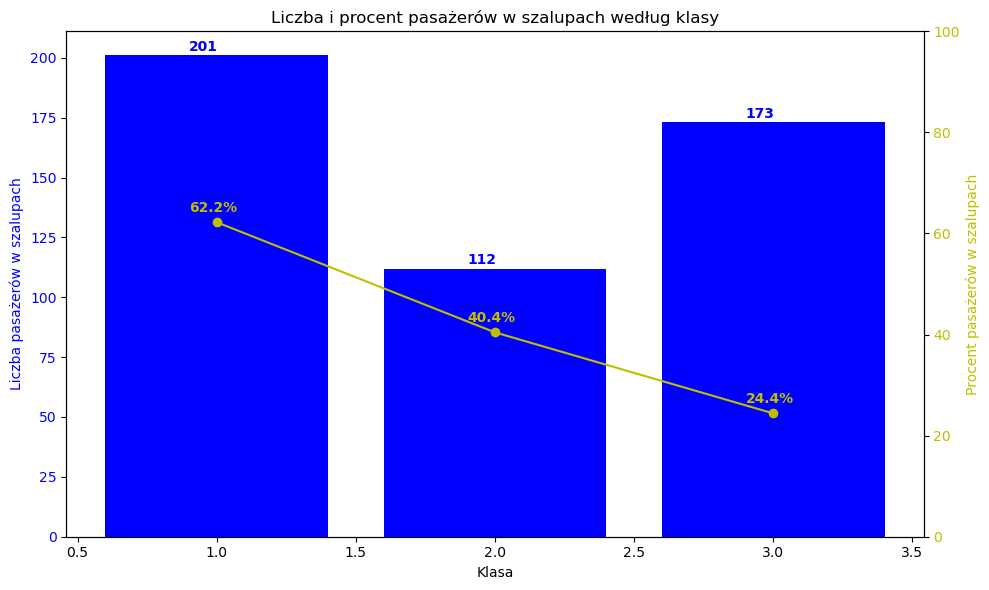

Trochę walczyłem z AI przez Data Chattera, żeby narysował mi wykres jakiego oczekiwałem.

- Nie udało mi się go skłonić do skorzystania wyłącznie z modułu pandas. Konsekwentnie dodawał moduł matplotlib.pyplot wieć ostatecznie to zaakceptowałem.
- Dostałem kilka razy odpowiedź "no result returned".
- W początkowych wersjach kodu dodawał linie wyjaśniające poszczególne kroki kodu. Później się już znudził i ostatecznie nie mam tych linii. To nauczka na przyszłość, żeby przy kolejnych iteracjach zachować sobie pierwszą wersję do podglądu. Inaczej trzeba będzie używać Code Explainera.

Wyniki są ciekawe. Widać, że pomimo zagrożenia załoga trzymała dyscyplinę na pokładzie.

- Do szalup wsiadali przede wszystkim pasażerowie pierwszej klasy. Z braku szalup (których było trzykrotnie za mało) i tak nie wszyscy się zmieścili, ale mieli zapewne pierwszeństwo.
- Pasażerów klasy drugiej było w ogóle najmniej, więc także w szalupach nie ma ich wielu, ale 40% ogółu pasażerów znalazło się w łodziach ratunkowych.
- Z klasy trzeciej do szalup wsiadło zaledwie 24% pasażerów, ale to i tak sporo biorąc pod uwagę ogólną liczbę osób podróżujących w tej klasie.

## Czy kobiety miały pierwszeństwo przy wsiadaniu do szalup?

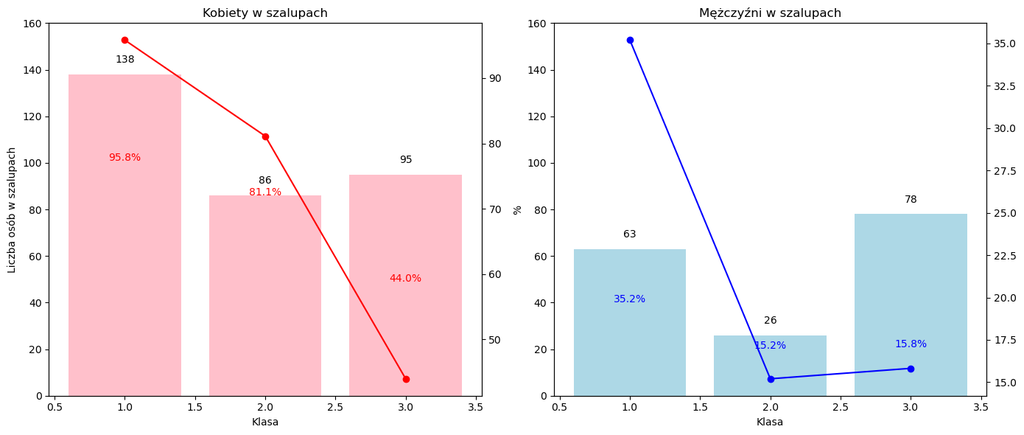

Dość długo walczyłem z tym podwójnym wykresem, ale w końcu się poddałem.

- Pomimo identycznych (tak mi się wydaje) kodów lewy i prawy wykres mają różne prawe skale y. Wykres dla kobiet ma prawą skalę y taką jak powinien mieć a wykres dla mężczyzn ma jakieś liczby od czapy. Nie umiem znaleźć w kodzie miejsca, które decyduje o tym problemie.
- Naklejki z odsedkiem pasażerów i pasażerek, którzy wsiedli do łodzi są w złych miejscach. Nie wiem jak działa ta formuła. Wygląda to jakby lokalizacja tych naklejek była przypisana do lewej skali y a nie do prawej.
- Góra też wygląda trochę nie bardzo. Przydałoby się więcej miejsca między wykresem i tytułem.

W realnej sytuacji z klientem zrobiłbym dwa oddzielne wykresy dla kobiet i dla mężczyzn, ale tutaj zostawię. Do ewentualnego poprawienia jak już ogarnę tę formułę rysowania.

Wniosek merytoryczny z analizy jest taki, że w pierwszej i drugiej klasie, przy wsiadaniu do szalup wyraźnie dawano pierwszeństwo kobietom. W trzeciej klasie też kobiety mają przewagę, ale nie jest to już tak ewidentne.

## Czy dzieci miały pierwszeństwo przy wsiadaniu do szalup?

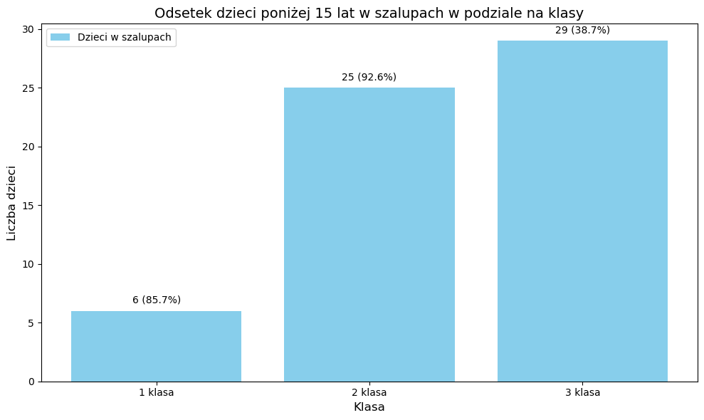

Refleksja techniczna: AI w postaci Data Chattera jest w znacznym stopniu nieprzewidywalny. Takie same lub podobne polecenia są wykonywane w bardzo różny sposób. Gdybym chciał mieć jeden standard wyglądu wykresów, to musiałbym chyba sporo potrenować współpracę z tą istotą :-).

Wniosek merytoryczny: generalnie widać, że starano się ratować dzieci we wszystkich klasach. W pierwszej i drugiej to się wyraźnie udało. W trzeciej - niestety pewnie tłok i chaos był za duży.

## Jakie szanse przeżycia miały osoby, które nie wsiadły do szalup

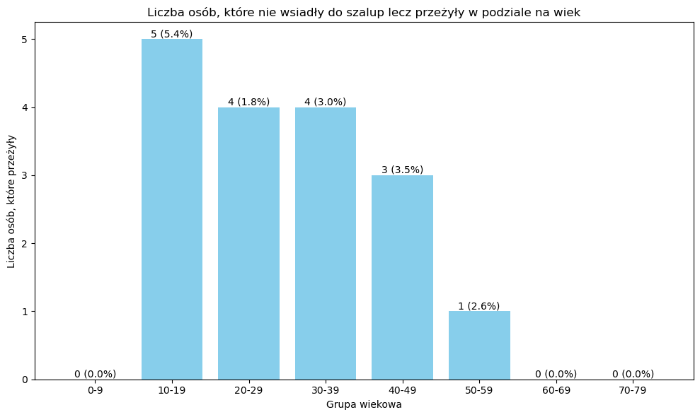

# Wnioski i pytania techniczne

To zadanie, jak rozumiem, miało pokazać, że ktoś kto nigdy nie programował w Pythonie, dzięki AI jest w stanie pisać programy i wykonywać dzięki nim złożone analizy. W moim przypadku tak się stało - zapanowałem nad danymi i zdołałem wyciągnąć z nich te informacje, których szukałem. Odebrałem też następujące lekcje:

1. Mam przyzwyczajenie z pracy na Excelu, że dla potrzeb mojej analizy zmieniam nazwy kolumn w taki sposób, żeby przy budowaniu tabel i wykresów wszystko było czytelne i zrozumiałe bez konieczności dodatkowej edycji. W przypadku pracy z AI to chyba bez sensu - edycja legend i tytułów nie jest uciążliwa.
2. W zasobach Pythona są niezliczone ilości pakietów, które AI zna a ja nie. Przydałaby się jakaś biblioteka czy lista.
3. Ja, przy pomocy Data Chattera formułuję polecenie, ale nie umiem dostatecznie precyzyjnie pokierować pracą aby dostawać powtarzalne wyniki. Nie chodzi mi o wyliczenia - te są powtarzalne - chodzi mi o format prezentacji, legendy, skale itp. Mam nadzieję, że tego mnie nauczycie.
4. Czasami mam wrażenie, że AI zachowuje się jak leniwy asystent. Za pierwszym razem coś zrobi w miarę starannie, ale gdy się go prosi o uzupełnienie czy poprawkę to efekt jest gorszy niż pierwotny. Łącznie z tym, że kilka razy dostałem odpowiedź: Unfortunately, I was not able to answer your question, because of the following error: No result returned